# About our World

amb54  
January 25, 2015

Course Project: Developing Data Products

### Learn more

…about our world and get to know your country, an important part of the world.  
Open data gotten from the World Bank show how different countries as well as the whole world have developed from 1961 up to recent years.  
The World Bank gathers data for each country in topics such as:  
Agriculture & Rural Development, Aid Effectiveness, Climate Change, Economy & Growth, Education, Energy & Mining, Environment, External Debt, Financial Sector, Gender, Health, Infrastructure, Poverty, Private Sector, Public Sector, Science & Technology, Social Development, Social Protection & Labor, Trade, Urban Development

### Indicators

Each topic have up to forty different indicators. The app include a few of those, primarily from the topics **Infrastructure** and **Health**.  
(The links below leads to the rawdata on the World Bank website.)  
[Population, total](http://data.worldbank.org/indicator/SP.POP.TOTL)  
[Arable land (hectares per person)](http://data.worldbank.org/indicator/AG.LND.ARBL.HA.PC)  
[GNI per capita based on purchasing power parity (PPP)](http://data.worldbank.org/indicator/NY.GNP.PCAP.PP.CD)  
[Improved water source, rural (% of rural population with access)](http://data.worldbank.org/indicator/SH.H2O.SAFE.RU.ZS)  
[Improved water source, urban (% of urban population with access)](http://data.worldbank.org/indicator/SH.H2O.SAFE.UR.ZS)  
[Access to electricity (% of population)](http://data.worldbank.org/indicator/EG.ELC.ACCS.ZS)  
[Internet users (per 100 people)](http://data.worldbank.org/indicator/IT.NET.USER.P2)  
[Motor vehicles (per 1,000 people)](http://data.worldbank.org/indicator/IS.VEH.NVEH.P3)  
[Fertility rate, total (births per woman)](http://data.worldbank.org/indicator/SP.DYN.TFRT.IN)  
[Mortality rate, under-5 (per 1,000 live births)](http://data.worldbank.org/indicator/SH.DYN.MORT)

### Example

This is how data of Denmarks total population from 1961 to 2012 looks like in the app

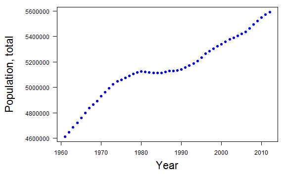

```r
par(mar = c(5.1, 8, 1, 1)); plot(plotData0, pch=20, ylab="",xlab="Year",cex = 1.5, col="blue", las=1,cex.lab=1.8); mtext(totalPop, side = 2, line = 6, cex=1.8)
```

### Go to...

[About our World](https://amb54.shinyapps.io/ProjDataProdDev/) and learn more!

Data used in this app is downloaded from  
[World Bank Open Data](http://data.worldbank.org/).

My hope is that anyone using this app will get even more curious about The World Bank Group, and their work to end extreme poverty and promote shared prosperity.  
Thank you!